# CPUE Training

Dan Ovando

October 11, 2016

# La estandarización de CPUE

CPUE es una de las metricos mas comunes para estimando el estado de poblacíones de pesces. La idea claramente es basico: si estas capturando menos pescado con el mismo esfuerzo, probablemte hay menos peses para capturar.

Pero, es util pensar un poco mas en lo que nos dice CPUE en realidad.

Pensamos en una ecuación basico de captura:

$$captura = biomasa * esfuerzo * capturabilidad$$

Por ejemplo, si hay 100 peses en un lago (*biomasa*), pesco por una hora con pintado (*esfuerzo*), y tengo una 10% probablidad de capturar qualquir peses encuentran my carnada sobre la hora (*capturabilidad*), voy a capturar 10 peses. Si le poblacion de peses baja a 50, entonces voy a capturar 5 peses.

Por esta relacion, podemos decir que

$$\frac{capture}{esfuerzo} = biomass * capturabilidad$$

o mas clara…

$$CPUE = qB$$

Entonces si B sube o baja, *CPUE* sube o baja. La problem aqui es que si tenemos ańos de *CPUE* datos, y tratamos de inferar el estado de la poblaciion (*B*) por la tendencias del *CPUE*.

Se puede ver que si CPUE cambia sobre tiempo, hay dos posibildades que pueden explicar esto: biomasa esta cambiando **o** *q* esta cambiando.

## Ejemplo

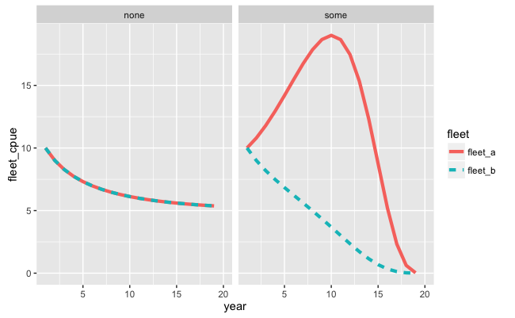

```r
fleets <- data_frame(effort = 10, q = 1, fleet = c('a','b'))
popfun <- function(r = 0.2,K = 1000,effort = 5,q = 0.01,qcreep = 1, years = 20){

  b <-  rep(NA, years)

  qseries <- rep(NA, years)

  catch <- rep(NA, years)

  fleet_a <- rep(NA, years)

  fleet_b <- rep(NA, years)

  b[1] <- K

  qseries[1] <- q

  for (t in 2:years) {
  catch[t - 1] <- b[t - 1] * (effort * qseries[t - 1]  +  effort * q)

  fleet_a[t - 1] <-
  catch[t - 1] * (effort * qseries[t - 1]) / (effort * qseries[t - 1]  +  effort *
  q)

  fleet_b[t - 1] <-
  catch[t - 1] * (effort * q) / (effort * qseries[t - 1]  +  effort * q)

  b[t] <- b[t - 1] + b[t - 1] * r * (1 - b[t - 1] / K) -  catch[t - 1]

  qseries[t] = qseries[t - 1] * qcreep

  }

  out <- data_frame(
  b = b,
  q = qseries,
  r = r,
  K = K,
  catch = catch,
  cpue = catch / effort,
  fleet_a = fleet_a,
  fleet_b = fleet_b,
  year = 1:years,
  effort = effort
  ) %>%
    gather(fleet,fleet_catch, fleet_a, fleet_b) %>%
    mutate(fleet_cpue = fleet_catch/effort, fleet_q = fleet_cpue / b)
  return(out)

}
nocreep <- popfun() %>%
  mutate(creep = 'none')
somecreep <- popfun(qcreep = 1.2) %>%
  mutate(creep = 'some')
cpue_example <- nocreep %>%
  bind_rows(somecreep)
cpue_example %>%
  select(year,fleet_cpue,fleet,creep) %>%
  ggplot(aes(year,fleet_cpue, color = fleet, linetype = fleet)) +
  geom_line(size = 1.5) +
  facet_wrap(~creep)
```

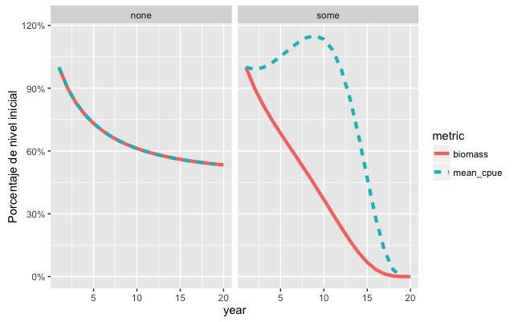

```r
cpue_example %>%
  group_by(year, creep) %>%
  summarise(biomass = mean(b, na.rm = T), mean_cpue = mean(fleet_cpue, na.rm = T),
            median_cpue = median(fleet_cpue, na.rm = T)) %>%
  gather(metric,value, biomass,mean_cpue) %>%
  group_by(creep, metric) %>%
  mutate(value = value/value[year == 1]) %>%
  ggplot(aes(year,value, color = metric, linetype = metric)) +
  geom_line(size = 1.5) +
  facet_wrap(~creep) +
  scale_y_continuous(name = 'Porcentaje de nivel inicial', labels = percent)
```

```r
NA
```

Como podemos coregir esto?

# Usando regression para estandarizacion

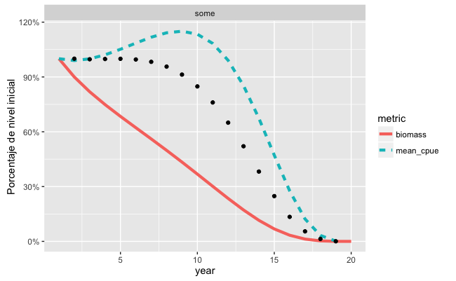